# R Final Exercise: NU-MSiA Bootcamp (Saleel Huprikar)

# Task 1: Import the data!

Download the nys_schools.csv data file!

```r
library(data.table)
nys_schools_data = fread("https://raw.githubusercontent.com/MSIA/bootcamp-2020/master/data/nys_schools.csv")
dim(nys_schools_data)
```

```
## [1] 35663    12
```

```r
head(nys_schools_data)
```

| school_cd | school_name | district_name | county_name | region | year | total_enroll | per_free_lunch | per_reduced_lunch | per_lep | mean_ela_score | mean_math_score |
| --- | --- | --- | --- | --- | --- | --- | --- | --- | --- | --- | --- |
| 10100010014 | MONTESSORI MAGNET SCHOOL | ALBANY CITY SCHOOL DISTRICT | ALBANY | CAPITAL DISTRICT | 2008 | 316 | 0.33 | 0.10 | 0.01 | 658.0000 | 669.6667 |
| 10100010014 | MONTESSORI MAGNET SCHOOL | ALBANY CITY SCHOOL DISTRICT | ALBANY | CAPITAL DISTRICT | 2009 | 312 | 0.32 | 0.08 | 0.02 | 672.6667 | 678.6667 |
| 10100010014 | MONTESSORI MAGNET SCHOOL | ALBANY CITY SCHOOL DISTRICT | ALBANY | CAPITAL DISTRICT | 2010 | 300 | 0.26 | 0.08 | 0.03 | 670.3333 | 683.0000 |
| 10100010014 | MONTESSORI MAGNET SCHOOL | ALBANY CITY SCHOOL DISTRICT | ALBANY | CAPITAL DISTRICT | 2011 | 326 | 0.22 | 0.07 | 0.03 | 666.6667 | 681.3333 |
| 10100010014 | MONTESSORI MAGNET SCHOOL | ALBANY CITY SCHOOL DISTRICT | ALBANY | CAPITAL DISTRICT | 2012 | 294 | 0.31 | 0.06 | 0.03 | 670.3333 | 687.3333 |
| 10100010014 | MONTESSORI MAGNET SCHOOL | ALBANY CITY SCHOOL DISTRICT | ALBANY | CAPITAL DISTRICT | 2013 | 321 | 0.25 | 0.08 | 0.03 | 309.6667 | 311.0000 |

Download the nys_acs data file!

```r
nys_acs_data = fread("https://raw.githubusercontent.com/MSIA/bootcamp-2020/master/data/nys_acs.csv")
dim(nys_acs_data)
```

```
## [1] 496   5
```

```r
head(nys_acs_data)
```

| county_name | year | county_per_poverty | median_household_income | county_per_bach |
| --- | --- | --- | --- | --- |
| ALBANY | 2009 | 0.1183511 | 55350 | 0.1903682 |
| ALBANY | 2010 | 0.1194052 | 56090 | 0.1971886 |
| ALBANY | 2011 | 0.1207243 | 57715 | 0.1989826 |
| ALBANY | 2012 | 0.1237525 | 59359 | 0.1975504 |
| ALBANY | 2013 | 0.1229728 | 59394 | 0.2045352 |
| ALBANY | 2014 | 0.1286178 | 59940 | 0.2011998 |

**What the variables mean in each dataset:**

# School data

school_cd = school id school_name = school name district_name = district name county_name = country name region = region of NYS year total_enroll = total enrollment for the school per_free_lunch = percent of students qualifying for free lunch per_reduced_lunch = percent of students qualifying for reduced price lunch per_lep = percent of students with limited english proficiency mean_ela_score = mean reading score for all grades in the school mean_math_score = mean math score for all grades in the school

# ACS data

name = county name year = year county_per_poverty median_household_income county_per_bach = percent over 25 with bachelors degree

# Task 2: Explore your data!

**Our two datasets (in R) are: nys_schools_data, nys_acs_data

```r
dim(nys_schools_data)
```

```
## [1] 35663    12
```

```r
dim(nys_acs_data)
```

```
## [1] 496   5
```

**Number of Unique School ids (unique schools) in the nys_schools_data**

```r
length(unique(nys_schools_data$school_cd)) #4027 unique school ids
```

```
## [1] 4027
```

**Number of Unique Counties in nys_acs_data**

```r
length(unique(nys_acs_data$county_name)) #62 unique counties
```

```
## [1] 62
```

**Let’s look at the variable types in each dataset**

```r
sapply(nys_schools_data, class)
```

```
##         school_cd       school_name     district_name       county_name
##       "integer64"       "character"       "character"       "character"
##            region              year      total_enroll    per_free_lunch
##       "character"         "integer"         "numeric"         "numeric"
## per_reduced_lunch           per_lep    mean_ela_score   mean_math_score
##         "numeric"         "numeric"         "numeric"         "numeric"
```

```r
sapply(nys_acs_data, class)
```

```
##             county_name                    year      county_per_poverty
##             "character"               "integer"               "numeric"
## median_household_income         county_per_bach
##               "integer"               "numeric"
```

**Let’s see if there is missing data in either dataset.**

**nys_schools_data**

```r
number_of_NA_values = function(x){ #the input is a column within the dataframe

  return (sum(!is.na(x) == F)) #Count up the number of Falses, which represents the number of NA values

}

apply(nys_schools_data, FUN = number_of_NA_values, MARGIN = 2)
```

```
##         school_cd       school_name     district_name       county_name
##                 0                 0                 0                 0
##            region              year      total_enroll    per_free_lunch
##                 0                 0                 0                 0
## per_reduced_lunch           per_lep    mean_ela_score   mean_math_score
##                 0                 0                 0                 0
```

**THERE ARE NO NA VALUES in the nys_schools_data dataset!**

**nys_acs_data**

```r
apply(nys_acs_data, FUN = number_of_NA_values, MARGIN = 2)
```

```
##             county_name                    year      county_per_poverty
##                       0                       0                       0
## median_household_income         county_per_bach
##                       0                       0
```

**THERE ARE NO NA in the nys_acs_data dataset!**

**Confirmation check: Counting the number of NA and non-NA values in each dataframe**

```r
summary(factor(!is.na(nys_schools_data)))
```

```
##   TRUE
## 427956
```

```r
summary(factor(!is.na(nys_acs_data)))
```

```
## TRUE
## 2480
```

**Good to go!**

# Although there are no explicit “NA” values in either dataframe, note that there may be missing data and that the missing data may be coded differently. It turns out there is missing data and we will be dealing with that below in the next task!

**How many years are available in each dataset?**

```r
unique(nys_schools_data$year) #2008-2017
```

```
##  [1] 2008 2009 2010 2011 2012 2013 2014 2015 2016 2017
```

```r
unique(nys_acs_data$year) #2009-2016
```

```
## [1] 2009 2010 2011 2012 2013 2014 2015 2016
```

# TASK 3: Recoding and variable manipulation

# nys_schools_data

```r
summary(nys_schools_data)
```

```
##    school_cd            school_name        district_name
##  Min.   : 10100010014   Length:35663       Length:35663
##  1st Qu.:280210030004   Class :character   Class :character
##  Median :331700011533   Mode  :character   Mode  :character
##  Mean   :356790938901
##  3rd Qu.:472506040001
##  Max.   :680801040002
##  county_name           region               year       total_enroll
##  Length:35663       Length:35663       Min.   :2008   Min.   : -99.0
##  Class :character   Class :character   1st Qu.:2010   1st Qu.: 339.0
##  Mode  :character   Mode  :character   Median :2013   Median : 469.0
##                                        Mean   :2013   Mean   : 523.6
##                                        3rd Qu.:2015   3rd Qu.: 648.0
##                                        Max.   :2017   Max.   :2347.0
##  per_free_lunch     per_reduced_lunch      per_lep
##  Min.   :-99.0000   Min.   :-99.00000   Min.   :-99.00000
##  1st Qu.:  0.1900   1st Qu.:  0.03000   1st Qu.:  0.00000
##  Median :  0.4200   Median :  0.06000   Median :  0.03000
##  Mean   :  0.4188   Mean   :  0.02852   Mean   :  0.04124
##  3rd Qu.:  0.7200   3rd Qu.:  0.10000   3rd Qu.:  0.11000
##  Max.   :257.0000   Max.   : 53.00000   Max.   :  1.00000
##  mean_ela_score  mean_math_score
##  Min.   :-99.0   Min.   :-99.0
##  1st Qu.:296.0   1st Qu.:298.0
##  Median :324.2   Median :330.8
##  Mean   :447.1   Mean   :456.0
##  3rd Qu.:666.3   3rd Qu.:683.5
##  Max.   :720.8   Max.   :738.7
```

**Notes:**** total_enroll, per_free_lunch, per_reduced_lunch, per_lep, mean_ela_score, and mean_math_score have negative values! (-99 values) per_free_lunch has values above 100; that makes no sense Is the ‘53’ in the per-reduced_lunch column supposed to be a percentage?**

**Let’s look at the three percent-based columns in more detail**

**Set of Unique Numbers that are greater than 1 and less than 0 for per_free_lunch**

```r
unique(nys_schools_data$per_free_lunch[(nys_schools_data$per_free_lunch > 1) | (nys_schools_data$per_free_lunch < 0)])
```

```
##  [1] -99.00   1.18   1.01   1.08   1.33   1.43   1.14   1.02   1.05   1.07
## [11]   1.06   1.03   1.09  22.06   1.16 257.00   1.83   2.38   1.25   1.87
## [21]   1.10   1.53   1.20   1.42   1.34   1.76
```

**Set of Unique Numbers that are greater than 1 and less than 0 for per_reduced_lunch**

```r
unique(nys_schools_data$per_reduced_lunch[(nys_schools_data$per_reduced_lunch > 1) | (nys_schools_data$per_reduced_lunch < 0)])
```

```
## [1] -99.00   2.18  53.00
```

**Set of Unique Numbers that are greater than 1 and less than 0 for per_lep**

```r
unique(nys_schools_data$per_lep[(nys_schools_data$per_lep > 1) | (nys_schools_data$per_lep < 0)])
```

```
## [1] -99
```

# OK, so I have determined from the unique number analysis above that the large majority of values for the three percent-based columns are between 0 and 1. I also learned that a value is NA if it is coded as “-99”. So, I will do two things. The first thing I will do is convert the “-99” values into NA values (i.e. I won’t delete them just yet; I’ll hang onto them, just in case I need them). Next, I will exclude the rows where there are values greater than 1 or less than 0 for any of the three percent-based columns; it turns out that the values are in decimal form, instead of percent form.

```r
nys_schools_data$total_enroll[nys_schools_data$total_enroll == -99] = NA
nys_schools_data$per_free_lunch[nys_schools_data$per_free_lunch == -99] = NA
nys_schools_data$per_reduced_lunch[nys_schools_data$per_reduced_lunch == -99] = NA
nys_schools_data$per_lep[nys_schools_data$per_lep == -99] = NA
nys_schools_data$mean_ela_score[nys_schools_data$mean_ela_score == -99] = NA
nys_schools_data$mean_math_score[nys_schools_data$mean_math_score == -99] = NA
```

```r
library(dplyr)
nys_schools_data_cleaned <- nys_schools_data %>%

                      filter(((per_free_lunch <= 1) & (per_free_lunch >= 0)) &
                      ((per_reduced_lunch <= 1) & (per_reduced_lunch >= 0)) &
                      ((per_lep <= 1) & (per_lep >= 0)))


dim(nys_schools_data_cleaned)
```

```
## [1] 35604    12
```

**No scores are below 0, good!**

```r
sum(nys_schools_data_cleaned$mean_ela_score < 0, na.rm = T)
```

```
## [1] 0
```

```r
sum(nys_schools_data_cleaned$mean_math_score < 0, na.rm = T)
```

```
## [1] 0
```

**In some rows of the nys_schools_data_cleaned, the percent free lunch + percent reduced lunch is greater than 1; it’s possible that there are people who qualify for both free and reduced lunch, but I don’t have that information available. To not complicate the analysis that I will do in future tasks, I will only retain entries where the percent free lunch + percent reduced lunch is less than or equal to 1**

```r
nys_schools_data_cleaned <- nys_schools_data_cleaned %>%

  filter(per_free_lunch + per_reduced_lunch <= 1)


dim(nys_schools_data_cleaned)
```

```
## [1] 35562    12
```

Confirmation Check:

```r
sum(nys_schools_data_cleaned$per_free_lunch + nys_schools_data_cleaned$per_reduced_lunch <= 1)
```

```
## [1] 35562
```

**Standardize the ela and math scores**

```r
nys_schools_data_cleaned <- nys_schools_data_cleaned %>%

  group_by(year) %>%

  mutate(ela_scaled_score = scale(mean_ela_score, center = mean(mean_ela_score,  na.rm = T)))
```

```r
nys_schools_data_cleaned <- nys_schools_data_cleaned %>%

  group_by(year) %>%

  mutate(math_scaled_score = scale(mean_math_score, center = mean(mean_math_score,  na.rm = T)))
```

```r
colnames(nys_schools_data_cleaned)
```

```
##  [1] "school_cd"         "school_name"       "district_name"
##  [4] "county_name"       "region"            "year"
##  [7] "total_enroll"      "per_free_lunch"    "per_reduced_lunch"
## [10] "per_lep"           "mean_ela_score"    "mean_math_score"
## [13] "ela_scaled_score"  "math_scaled_score"
```

```r
nys_schools_data_cleaned <- nys_schools_data_cleaned %>%

  filter(county_name != "-99")
```

# nys_acs_data

```r
summary(nys_acs_data)
```

```
##  county_name             year      county_per_poverty
##  Length:496         Min.   :2009   Min.   :0.04689
##  Class :character   1st Qu.:2011   1st Qu.:0.10903
##  Mode  :character   Median :2012   Median :0.12884
##                     Mean   :2012   Mean   :0.13085
##                     3rd Qu.:2014   3rd Qu.:0.14929
##                     Max.   :2016   Max.   :0.29935
##  median_household_income county_per_bach
##  Min.   : 33794          Min.   :0.07574
##  1st Qu.: 46347          1st Qu.:0.11018
##  Median : 50134          Median :0.13169
##  Mean   : 54116          Mean   :0.14410
##  3rd Qu.: 56448          3rd Qu.:0.17431
##  Max.   :102044          Max.   :0.31795
```

```r
sum(as.matrix(nys_acs_data) == -99) #"-99" does not appear anywhere in this dataset!
```

```
## [1] 0
```

**I am going to create a high,medium,low poverty variable for each county; I will use the poverty definitions from the Pew Research Center, which are as follows: Low (<= 7 percent in poverty), Medium (between 7 and 23 percent in poverty), and High (>= 23 percent in poverty)**

```r
nys_acs_data$Poverty_Level = NA

nys_acs_data$Poverty_Level[nys_acs_data$county_per_poverty <= 0.07] = "Low"

nys_acs_data$Poverty_Level[(nys_acs_data$county_per_poverty > 0.07) &
                            (nys_acs_data$county_per_poverty < 0.23)] = "Medium"

nys_acs_data$Poverty_Level[nys_acs_data$county_per_poverty >= 0.23] = "High"
summary(factor(nys_acs_data$Poverty_Level))
```

```
##   High    Low Medium
##     10     31    455
```

**We will proceed with the following datasets: nys_schools_data_cleaned, nys_acs_data**

# Task 4: Merge Datasets

**Create a county-level dataset that merges variables from the schools dataset and the ACS dataset.**

```r
colnames(nys_schools_data_cleaned)
```

```
##  [1] "school_cd"         "school_name"       "district_name"
##  [4] "county_name"       "region"            "year"
##  [7] "total_enroll"      "per_free_lunch"    "per_reduced_lunch"
## [10] "per_lep"           "mean_ela_score"    "mean_math_score"
## [13] "ela_scaled_score"  "math_scaled_score"
```

```r
colnames(nys_acs_data)
```

```
## [1] "county_name"             "year"
## [3] "county_per_poverty"      "median_household_income"
## [5] "county_per_bach"         "Poverty_Level"
```

**Common variables: County Name/Year**

```r
library(dplyr)
merged_data <- left_join(nys_schools_data_cleaned, nys_acs_data, by = c('county_name', 'year')) #Only 2009-2016 years will have county data because 2008 and 2017 are not in county dataset
```

# Task 5: Create Summary Tables

**For each county: total enrollment, percent of students qualifying for free or reduced price lunch, and percent of population in poverty.**

```r
merged_data$Number_of_Students_Free_Reduced_Lunch =  (merged_data$per_free_lunch + merged_data$per_reduced_lunch)*(merged_data$total_enroll)
```

```r
colnames(merged_data)
```

```
##  [1] "school_cd"
##  [2] "school_name"
##  [3] "district_name"
##  [4] "county_name"
##  [5] "region"
##  [6] "year"
##  [7] "total_enroll"
##  [8] "per_free_lunch"
##  [9] "per_reduced_lunch"
## [10] "per_lep"
## [11] "mean_ela_score"
## [12] "mean_math_score"
## [13] "ela_scaled_score"
## [14] "math_scaled_score"
## [15] "county_per_poverty"
## [16] "median_household_income"
## [17] "county_per_bach"
## [18] "Poverty_Level"
## [19] "Number_of_Students_Free_Reduced_Lunch"
```

```r
merged_data %>%

  group_by(county_name, year) %>%



  summarize(Total_Enrollment = sum(total_enroll, na.rm = T),
            Percent_Of_Population_In_Poverty = 100*unique(county_per_poverty),
            Percent_Of_Students_Qualifying_For_Free_Or_Reduced_Lunch = 100*(sum(Number_of_Students_Free_Reduced_Lunch, na.rm = T)/sum(total_enroll, na.rm = T)))
```

| county_name | year | Total_Enrollment | Percent_Of_Population_In_Poverty | Percent_Of_Students_Qualifying_For_Free_Or_Reduced_Lunch |
| --- | --- | --- | --- | --- |
| ALBANY | 2008 | 23268 | NA | 35.921824 |
| ALBANY | 2009 | 25830 | 11.835115 | 37.145296 |
| ALBANY | 2010 | 26620 | 11.940519 | 36.582269 |
| ALBANY | 2011 | 26316 | 12.072431 | 37.102941 |
| ALBANY | 2012 | 25212 | 12.375251 | 38.323378 |
| ALBANY | 2013 | 25688 | 12.297276 | 40.229718 |
| ALBANY | 2014 | 25663 | 12.861782 | 41.185754 |
| ALBANY | 2015 | 26000 | 12.797963 | 40.388423 |
| ALBANY | 2016 | 25895 | 12.260508 | 40.726665 |
| ALBANY | 2017 | 26340 | NA | 39.126614 |

[output cut: 610 more lines]

**For the counties with the top 5 and bottom 5 poverty rate: percent of population in poverty, percent of students qualifying for free or reduced price lunch, mean reading score, and mean math score.**

Let’s find the average poverty rate of each county over time. Then, we’ll find the counties with the highest 5 and lowest 5 average poverty rates.

```r
Average_Poverty_Rates_Of_Counties = nys_acs_data %>%

  group_by(county_name) %>%

  summarize(Average_Poverty_Rate = mean(county_per_poverty, na.rm = T))

Average_Poverty_Rates_Of_Counties[order(Average_Poverty_Rates_Of_Counties$Average_Poverty_Rate, decreasing = T),]
```

| county_name | Average_Poverty_Rate |
| --- | --- |
| BRONX | 0.28671474 |
| KINGS | 0.22447711 |
| MONTGOMERY | 0.17758851 |
| CHAUTAUQUA | 0.17525204 |
| TOMPKINS | 0.17502098 |
| NEW YORK | 0.17157538 |
| CATTARAUGUS | 0.16518143 |
| SULLIVAN | 0.16402394 |
| SAINT LAWRENCE | 0.16353773 |
| OSWEGO | 0.16167814 |

[output cut: 52 more lines]

The top 5 counties: Bronx, Kings, Montgomery, Chautauqua, Tompkins The bottom 5 counties: Dutchess, Saratoga, Suffolk, Putnam, Nassau

```r
merged_data %>%

  filter(county_name == 'BRONX' | county_name == 'KINGS' | county_name == 'MONTGOMERY'
         | county_name == 'CHAUTAUQUA' | county_name == 'TOMPKINS' |
           county_name == 'DUTCHESS' | county_name == 'SARATOGA' |
           county_name == 'SUFFOLK' | county_name == 'PUTNAM' |
           county_name == 'NASSAU') %>%

  group_by(county_name, year) %>%


  summarize(Percent_Of_Population_In_Poverty = 100*unique(county_per_poverty),
            Percent_Of_Students_Qualifying_For_Free_Or_Reduced_Lunch = 100*(sum(Number_of_Students_Free_Reduced_Lunch, na.rm = T)/sum(total_enroll, na.rm = T)),
            Mean_ELA_Score = mean(mean_ela_score, na.rm = T),
            Mean_Math_Score = mean(mean_math_score, na.rm = T))
```

| county_name | year | Percent_Of_Population_In_Poverty | Percent_Of_Students_Qualifying_For_Free_Or_Reduced_Lunch | Mean_ELA_Score | Mean_Math_Score |
| --- | --- | --- | --- | --- | --- |
| BRONX | 2008 | NA | 86.642753 | 647.6561 | 663.9752 |
| BRONX | 2009 | 27.105330 | 87.285054 | 655.6598 | 672.8092 |
| BRONX | 2010 | 27.580955 | 86.910490 | 656.2730 | 672.4312 |
| BRONX | 2011 | 27.730317 | 86.709891 | 655.9925 | 672.9827 |
| BRONX | 2012 | 28.551809 | 85.597287 | 657.7098 | 674.4621 |
| BRONX | 2013 | 29.017437 | 85.577733 | 286.8373 | 287.6323 |
| BRONX | 2014 | 29.682378 | 86.119178 | 286.8165 | 290.7097 |
| BRONX | 2015 | 29.934673 | 85.296166 | 288.0301 | 290.5461 |
| BRONX | 2016 | 29.768894 | 84.221990 | 295.7927 | 291.0076 |
| BRONX | 2017 | NA | 84.422264 | 297.8094 | 291.5721 |

[output cut: 90 more lines]

# Task 6: Data Visualization

Using ggplot2, visualize the following:

**The relationship between access to free/reduced price lunch and test performance, at the school level.**

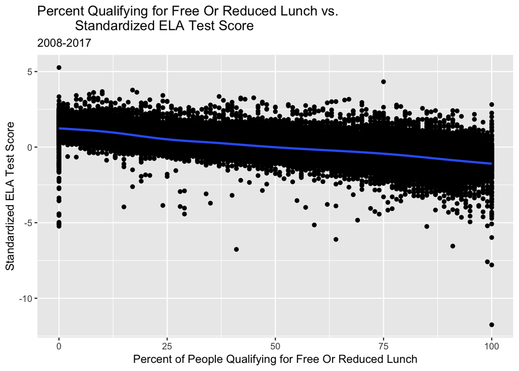

```r
library(ggplot2)
nys_schools_data_cleaned %>%

  ggplot() +

  geom_point(aes(x = 100*(per_reduced_lunch + per_free_lunch),y = ela_scaled_score)) +

  geom_smooth(aes(x = 100*(per_reduced_lunch + per_free_lunch),y = ela_scaled_score)) +

  ggtitle("Percent Qualifying for Free Or Reduced Lunch vs.
          Standardized ELA Test Score", subtitle = "2008-2017") +

  labs(x = "Percent of People Qualifying for Free Or Reduced Lunch", y = "Standardized ELA Test Score")
```

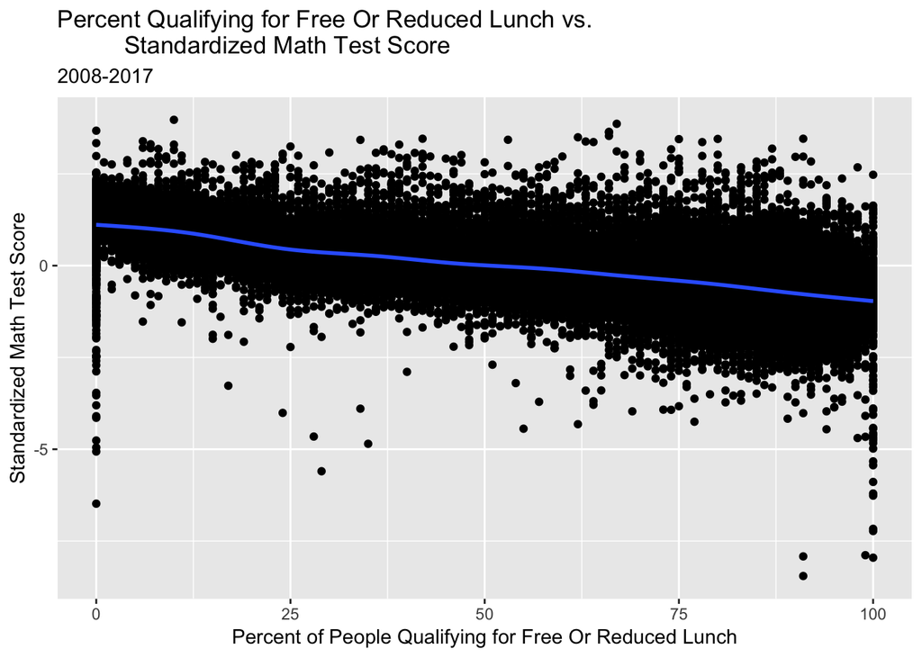

```r
nys_schools_data_cleaned %>%

  ggplot() +

  geom_point(aes(x = 100*(per_reduced_lunch + per_free_lunch),y = math_scaled_score)) +

  geom_smooth(aes(x = 100*(per_reduced_lunch + per_free_lunch),y = math_scaled_score)) +

  ggtitle("Percent Qualifying for Free Or Reduced Lunch vs.
          Standardized Math Test Score", subtitle = "2008-2017") +

  labs(x = "Percent of People Qualifying for Free Or Reduced Lunch", y = "Standardized Math Test Score")
```

Average test performance across counties with high, low, and medium poverty.

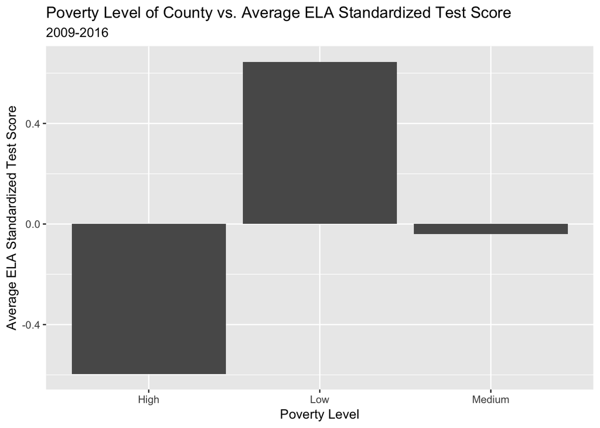

```r
Test_Breakdown_By_Poverty_Level <- merged_data %>%

  filter(!is.na(Poverty_Level) == TRUE) %>%

  group_by(Poverty_Level) %>%

  summarize(Average_ela_scaled_score = mean(ela_scaled_score, na.rm = T),
            Average_math_scaled_score = mean(math_scaled_score, na.rm = T))


par(mfrow=c(1,2))

ggplot(Test_Breakdown_By_Poverty_Level) +

  geom_col(aes(x = Poverty_Level, y = Average_ela_scaled_score)) +

  ggtitle("Poverty Level of County vs. Average ELA Standardized Test Score",
          subtitle = "2009-2016") +

  labs(x = "Poverty Level", y = "Average ELA Standardized Test Score")
```

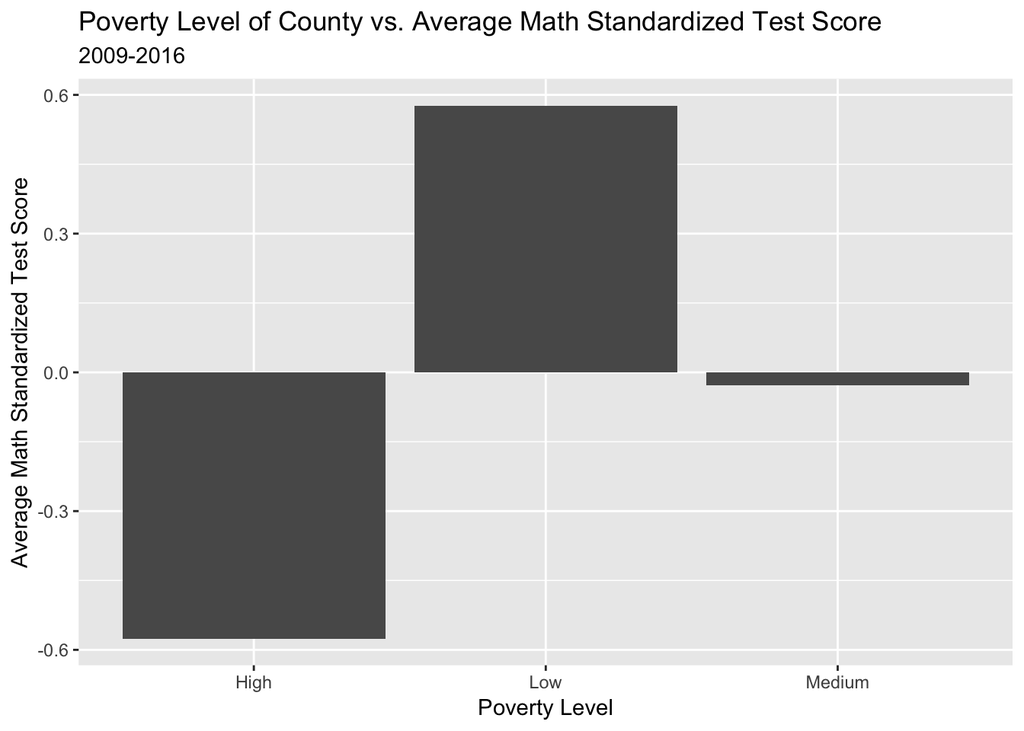

```r
ggplot(Test_Breakdown_By_Poverty_Level) +

  geom_col(aes(x = Poverty_Level, y = Average_math_scaled_score)) +

  ggtitle("Poverty Level of County vs. Average Math Standardized Test Score",
          subtitle = "2009-2016") +

  labs(x = "Poverty Level", y = "Average Math Standardized Test Score")
```